# Exploration — QuantFlow Gold

Notebook d'**overview complet** des connecteurs actifs (post-cleanup, **section crypto retirée**). Chaque section explore une famille de signaux sur l'or, avec un plot + commentaire bref.

**Pré-requis** : `pandas`, `duckdb`, `matplotlib`, `numpy`, `python-dotenv`. Le notebook charge `datascrap/.env` et lit les parquets sous `DATA_DIR/processed` (comme le CLI) ou par défaut `datascrap/data/processed`. Si FRED n’apparaît pas alors que le run a réussi, vérifiez que le CLI et le notebook pointent vers le même `DATA_DIR`.

**Plan** :

**Règles globales** :

- axe X : libellés majeurs `YYYY` ou `YYYY-MM` selon la fenêtre, **ticks mineurs mensuels** systématiques,
- échelle **log** dès que l'amplitude relative entre séries dépasse 5×,
- unités extraites du parquet via `unit_for(metric)`,
- bandeau gris si moins de 90j d'historique,
- caption 1-line sous chaque plot.

```python
import os
import duckdb
import numpy as np
import pandas as pd
from pathlib import Path

from dotenv import load_dotenv

import matplotlib.pyplot as plt
import matplotlib.dates as mdates

plt.rcParams.update({
    "figure.figsize": (11, 4),
    "figure.dpi": 110,
    "axes.grid": True,
    "grid.alpha": 0.25,
    "axes.titlesize": 11,
    "axes.labelsize": 9,
    "legend.fontsize": 8,
    "xtick.labelsize": 9,
    "ytick.labelsize": 9,
})


def fmt_date_axis(ax):
    """Axe X adaptatif :
    - >15 ans : majeur tous les 3 ans (YYYY) + mineur annuel
    - 7-15 ans : majeur annuel (YYYY) + mineur trimestriel
    - 2-7 ans : majeur tous les 6 mois (YYYY-MM) + mineur mensuel
    - 1-2 ans : majeur trimestriel (YYYY-MM) + mineur mensuel
    - 6-12 mois : majeur tous les 2 mois + mineur mensuel
    - < 6 mois : majeur mensuel (YYYY-MM) + mineur hebdo
    """
    x0, x1 = ax.get_xlim()
    if (x1 - x0) <= 0 or not np.isfinite([x0, x1]).all():
        loc = mdates.AutoDateLocator(minticks=6, maxticks=12)
        ax.xaxis.set_major_locator(loc)
        ax.xaxis.set_major_formatter(mdates.ConciseDateFormatter(loc))
        ax.tick_params(axis="x", labelbottom=True)
        return

    span_days = (mdates.num2date(x1) - mdates.num2date(x0)).days
    rotation = 0
    if span_days > 15 * 365:
        ax.xaxis.set_major_locator(mdates.YearLocator(base=3))
        ax.xaxis.set_major_formatter(mdates.DateFormatter("%Y"))
        ax.xaxis.set_minor_locator(mdates.YearLocator(base=1))
    elif span_days > 7 * 365:
        ax.xaxis.set_major_locator(mdates.YearLocator(base=1))
        ax.xaxis.set_major_formatter(mdates.DateFormatter("%Y"))
        ax.xaxis.set_minor_locator(mdates.MonthLocator(bymonth=[1, 4, 7, 10]))
    elif span_days > 2 * 365:
        ax.xaxis.set_major_locator(mdates.MonthLocator(bymonth=[1, 7]))
        ax.xaxis.set_major_formatter(mdates.DateFormatter("%Y-%m"))
        ax.xaxis.set_minor_locator(mdates.MonthLocator())
        rotation = 30
    elif span_days > 365:
        ax.xaxis.set_major_locator(mdates.MonthLocator(bymonth=[1, 4, 7, 10]))
        ax.xaxis.set_major_formatter(mdates.DateFormatter("%Y-%m"))
        ax.xaxis.set_minor_locator(mdates.MonthLocator())
        rotation = 30
    elif span_days > 180:
        ax.xaxis.set_major_locator(mdates.MonthLocator(interval=2))
        ax.xaxis.set_major_formatter(mdates.DateFormatter("%Y-%m"))
        ax.xaxis.set_minor_locator(mdates.MonthLocator())
        rotation = 30
    else:
        ax.xaxis.set_major_locator(mdates.MonthLocator())
        ax.xaxis.set_major_formatter(mdates.DateFormatter("%Y-%m"))
        ax.xaxis.set_minor_locator(mdates.WeekdayLocator(byweekday=mdates.MO))
        rotation = 30

    ax.tick_params(axis="x", which="major", labelbottom=True)
    ax.tick_params(axis="x", which="minor", length=3, color="#aaa")
    if rotation:
        for lab in ax.get_xticklabels():
            lab.set_rotation(rotation)
            lab.set_ha("right")


def legend_outside(ax, ncol=1, loc="center left", anchor=(1.02, 0.5)):
    """Pousse la légende hors du cadre du plot pour éviter de masquer les courbes."""
    return ax.legend(loc=loc, bbox_to_anchor=anchor, ncol=ncol, frameon=False)


def unit_for(metric: str, default: str = "") -> str:
    """Lookup canonique de l'unité pour un metric (long-format)."""
    try:
        df = q(f"""SELECT unit
                   FROM read_parquet('{{glob}}', union_by_name=true)
                   WHERE metric = '{metric}' AND unit IS NOT NULL LIMIT 1""")
        if len(df) and pd.notna(df.iloc[0, 0]):
            return str(df.iloc[0, 0])
    except Exception:
        pass
    return default


def insufficient_history(ax, series, min_days=90,
                         msg="Historique insuffisant pour signal fiable"):
    """Bandeau gris si la série a < min_days observations."""
    n = pd.Series(series).dropna().shape[0]
    if n < min_days:
        ax.text(
            0.5, 0.5, f"{msg}\n({n} obs)",
            transform=ax.transAxes, ha="center", va="center",
            fontsize=11, color="#555",
            bbox=dict(boxstyle="round,pad=0.6",
                      facecolor="#e8e8e8", edgecolor="#bbb", alpha=0.9),
        )
        ax.set_xticks([])
        ax.set_yticks([])
        return True
    return False


def caption(text):
    """Insight 1-line factuel sous chaque plot."""
    print(f"  > {text}")


REPO = Path("..").resolve()
load_dotenv(REPO / ".env")

# Aligné sur quantflow_gold : si DATA_DIR est défini, les parquets sont dans
#   <DATA_DIR>/processed/<source>/latest.parquet
# Sinon : <repo>/data/processed/...
_data_root = os.environ.get("DATA_DIR")
if _data_root:
    DATA = Path(_data_root).expanduser().resolve() / "processed"
else:
    DATA = REPO / "data" / "processed"

_home_fred = Path.home() / "data" / "processed" / "fred"
if not (DATA / "fred").exists() and _home_fred.is_dir():
    print(
        "⚠ FRED est dans ~/data/processed/fred mais pas dans le dossier lu par ce notebook.\n"
        f"   Lu actuellement : {DATA.resolve()}\n"
        "   Cause fréquente : le CLI a été lancé avec DATA_DIR=~/data (ou .env ailleurs).\n"
        "   Fix : ajoutez dans datascrap/.env une ligne DATA_DIR=.../datascrap/data\n"
        "   puis relancez : python -m quantflow_gold.run -s fred\n"
        f"   Ou lien symbolique : ln -s {_home_fred} {DATA / 'fred'}"
    )

GLOB = str(DATA / "*" / "latest.parquet")
con = duckdb.connect()


def q(sql: str) -> pd.DataFrame:
    return con.sql(sql.format(glob=GLOB)).df()


print("Parquets :", DATA.resolve())
print("Sources disponibles :", sorted(p.name for p in DATA.glob("*") if p.is_dir()))
```

```
Parquets : /Users/lucasteyssier/datascrap/data/processed
Sources disponibles : ['binance_gold', 'central_bank_gold', 'cftc_cot', 'coingecko_gold', 'comex_stocks', 'defillama', 'etf_holdings', 'fred', 'gdelt', 'google_trends', 'historical_long', 'miners_yahoo', 'mining_news', 'open_meteo', 'perth_mint', 'sec_edgar', 'sge', 'stocktwits', 'treasury_tga', 'us…
```

```python
summary = q("""
    SELECT source,
           COUNT(*)               AS rows,
           COUNT(DISTINCT metric) AS metrics,
           MIN(date)              AS first_date,
           MAX(date)              AS last_date
    FROM read_parquet('{glob}', union_by_name=True)
    GROUP BY source
    ORDER BY rows DESC
""")
print(f"Total: {summary['rows'].sum():,} lignes / {summary['metrics'].sum()} metrics distincts / {len(summary)} sources")
summary
```

```
Total: 2,949,901 lignes / 1212 metrics distincts / 22 sources
```

|  | source | rows | metrics | first_date | last_date |
| --- | --- | --- | --- | --- | --- |
| 0 | yahoo | 2149830 | 390 | 1996-01-01 00:00:00 | 2026-04-25 00:00:00 |
| 1 | etf_holdings | 170437 | 50 | 2008-09-30 00:00:00 | 2026-04-24 00:00:00 |
| 2 | historical_long | 159585 | 35 | 2005-01-03 00:00:00 | 2026-04-24 00:00:00 |
| 3 | open_meteo | 87648 | 48 | 2021-04-24 00:00:00 | 2026-04-23 00:00:00 |
| 4 | fred | 77221 | 30 | 2010-01-01 00:00:00 | 2026-04-27 00:00:00 |
| 5 | binance_gold | 70843 | 80 | 2019-01-01 00:00:00 | 2026-04-25 00:00:00 |
| 6 | miners_yahoo | 51743 | 11 | 2000-08-30 00:00:00 | 2026-04-24 00:00:00 |
| 7 | google_trends | 35235 | 135 | 2021-04-25 00:00:00 | 2026-04-19 00:00:00 |
| 8 | wikipedia | 34694 | 19 | 2021-04-25 00:00:00 | 2026-04-24 00:00:00 |
| 9 | gdelt | 23738 | 22 | 2023-04-26 00:00:00 | 2026-04-25 00:00:00 |
| 10 | cftc_cot | 23220 | 45 | 2015-01-06 00:00:00 | 2026-04-21 00:00:00 |
| 11 | defillama | 23180 | 56 | 2017-09-27 00:00:00 | 2026-04-25 00:00:00 |
| 12 | usgs_earthquakes | 16791 | 33 | 2021-04-26 00:00:00 | 2026-04-24 00:00:00 |
| 13 | treasury_tga | 15303 | 6 | 2010-01-04 00:00:00 | 2026-04-23 00:00:00 |
| 14 | sec_edgar | 7300 | 64 | 2002-02-01 00:00:00 | 2026-04-23 00:00:00 |
| 15 | us_mint | 1260 | 4 | 1986-10-01 00:00:00 | 2012-12-01 00:00:00 |
| 16 | sge | 985 | 24 | 2024-01-26 00:00:00 | 2026-04-24 00:00:00 |
| 17 | coingecko_gold | 568 | 28 | 2026-01-26 00:00:00 | 2026-04-25 12:29:31 |
| 18 | mining_news | 147 | 14 | 2026-03-22 09:32:14 | 2026-04-24 11:06:00 |
| 19 | stocktwits | 60 | 60 | 2026-04-25 00:00:00 | 2026-04-25 00:00:00 |
| 20 | perth_mint | 59 | 4 | 2024-10-01 00:00:00 | 2026-03-01 00:00:00 |
| 21 | central_bank_gold | 54 | 54 | 2026-04-25 00:00:00 | 2026-04-25 00:00:00 |

## 2. Prix de l'or & macro

**Panel 1** : prix nominal du gold front-month (futures COMEX) sur toute la fenêtre. **Panel 2a** : `Gold`, `Silver`, `S&P 500` rebasés à 100 (échelle log) — comparable car ce sont des prix. **Panel 2b** : `VIX` (points) et `US10Y yield` (%) sur leurs niveaux natifs — ce sont des indices, pas des prix, leur normalisation à base 100 serait trompeuse. DXY n'est pas tracé (déjà un index, traité dans la matrice de corrélation §13).

```python
macro = q("""
    SELECT date, metric, value
    FROM read_parquet('{glob}', union_by_name=true)
    WHERE source = 'yahoo'
      AND metric IN (
        'gold_futures_front_close','silver_futures_front_close',
        'dxy_close','us10y_yield_close','vix_close','sp500_close')
""")
wide = (macro.assign(date=lambda d: pd.to_datetime(d["date"]))
              .pivot_table(index="date", columns="metric",
                           values="value", aggfunc="last")
              .sort_index())
wide = wide.ffill(limit=5)

NORM_COLS = [
    "gold_futures_front_close",
    "sp500_close",
    "us10y_yield_close",
    "vix_close",
    "silver_futures_front_close",
]
norm_cols = [c for c in NORM_COLS if c in wide.columns]
_complete = wide[norm_cols].dropna(how="any")
if _complete.empty:
    raise RuntimeError("Pas de ligne commune pour toutes les séries macro — vérifie data/processed/yahoo/")
anchor = _complete.index.min()
base = wide.loc[anchor, norm_cols]
norm = wide[norm_cols].divide(base).multiply(100)

print("Macro (Yahoo) :", wide.index.min().date(), "→", wide.index.max().date(), "—", len(wide), "jours")
print("  Ancrage base 100 cross-asset (toutes séries non-NaN) :", anchor.date())
print("  1ère cotation GC=F :", wide["gold_futures_front_close"].first_valid_index().date())
```

```
Macro (Yahoo) : 1996-01-01 → 2026-04-24 — 7695 jours
  Ancrage base 100 cross-asset (toutes séries non-NaN) : 2000-08-30
  1ère cotation GC=F : 2000-08-30
```

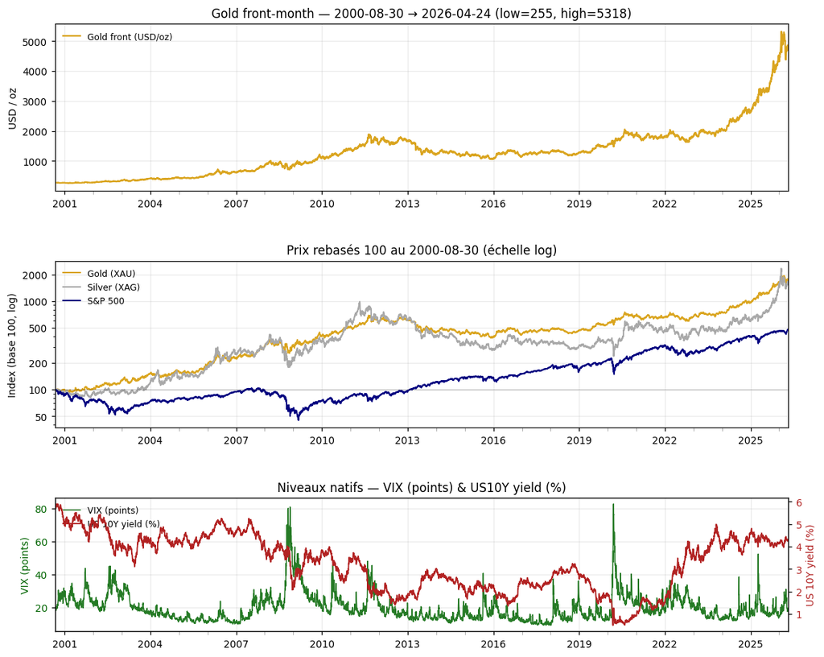

```
  > Gold +1624% depuis 2000-08-30 ; prix en log (panel 2a) et niveaux natifs VIX/US10Y (panel 2b) — pas de comparaison artificielle entre prix et indices.
Δ prix depuis base 100 (%) :
metric
gold_futures_front_close      1624.1
silver_futures_front_close    1449.4
sp500_close                    376.8
VIX last = 18.7 pts ; US10Y last = 4.31%
```

```python
fig = plt.figure(figsize=(12, 10))
gs = fig.add_gridspec(3, 1, height_ratios=[1.0, 1.0, 0.8], hspace=0.45)
ax1 = fig.add_subplot(gs[0])
ax2a = fig.add_subplot(gs[1])
ax2b = fig.add_subplot(gs[2])

g = wide["gold_futures_front_close"].dropna()
ax1.plot(g.index, g, color="goldenrod", lw=1.5, label="Gold front (USD/oz)")
ax1.set_xlim(g.index[0], g.index[-1])
ax1.set_ylabel("USD / oz")
ax1.set_title(f"Gold front-month — {g.index[0].date()} → {g.index[-1].date()} "
              f"(low={g.min():.0f}, high={g.max():.0f})")
ax1.legend(loc="upper left", frameon=False)
fmt_date_axis(ax1)

# Panel 2a : prix base 100 log
import matplotlib.ticker as mticker
norm_plot = norm.loc[anchor:]
PRICE_PALETTE = [
    ("gold_futures_front_close",   "goldenrod", "Gold (XAU)"),
    ("silver_futures_front_close", "darkgray",  "Silver (XAG)"),
    ("sp500_close",                "navy",      "S&P 500"),
]
for col, color, label in PRICE_PALETTE:
    if col in norm_plot.columns:
        s = norm_plot[col].dropna()
        if len(s):
            ax2a.plot(s.index, s, color=color, label=label, lw=1.3)
ax2a.axhline(100, color="k", alpha=0.3, lw=0.5)
ax2a.set_yscale("log")
ax2a.yaxis.set_major_locator(mticker.LogLocator(base=10, subs=[1, 2, 5]))
ax2a.yaxis.set_major_formatter(mticker.ScalarFormatter())
ax2a.set_xlim(anchor, norm_plot.index[-1])
ax2a.set_title(f"Prix rebasés 100 au {anchor.date()} (échelle log)")
ax2a.set_ylabel("Index (base 100, log)")
ax2a.legend(loc="upper left", frameon=False)
fmt_date_axis(ax2a)

# Panel 2b : niveaux VIX (points) + US10Y (%) sur axe linéaire avec twinx
ax2b_r = ax2b.twinx()
if "vix_close" in wide.columns:
    s = wide["vix_close"].dropna()
    s = s.loc[anchor:]
    ax2b.plot(s.index, s, color="darkgreen", lw=1, alpha=0.85, label="VIX (points)")
    ax2b.set_ylabel("VIX (points)", color="darkgreen")
    ax2b.tick_params(axis="y", labelcolor="darkgreen")
if "us10y_yield_close" in wide.columns:
    s = wide["us10y_yield_close"].dropna()
    s = s.loc[anchor:]
    ax2b_r.plot(s.index, s, color="firebrick", lw=1.2, label="US 10Y yield (%)")
    ax2b_r.set_ylabel("US 10Y yield (%)", color="firebrick")
    ax2b_r.tick_params(axis="y", labelcolor="firebrick")
    ax2b_r.grid(False)
ax2b.set_xlim(anchor, norm_plot.index[-1])
ax2b.set_title("Niveaux natifs — VIX (points) & US10Y yield (%)")
lines = ax2b.get_lines() + ax2b_r.get_lines()
ax2b.legend(lines, [l.get_label() for l in lines], loc="upper left", frameon=False)
fmt_date_axis(ax2b)

plt.show()

last_gold = g
delta = (last_gold.iloc[-1] / last_gold.iloc[0] - 1) * 100
caption(f"Gold {delta:+.0f}% depuis {g.index[0].date()} ; prix en log (panel 2a) et niveaux natifs VIX/US10Y (panel 2b) — pas de comparaison artificielle entre prix et indices.")
deltas = (norm_plot[[c for c, _, _ in PRICE_PALETTE if c in norm_plot.columns]].iloc[-1] - 100).round(1).sort_values(ascending=False)
print("Δ prix depuis base 100 (%) :")
print(deltas.to_string())
print(f"VIX last = {wide['vix_close'].dropna().iloc[-1]:.1f} pts ; "
      f"US10Y last = {wide['us10y_yield_close'].dropna().iloc[-1]:.2f}%")
```

## 3. Spreads cross-asset

Ratios calculés en amont par le connecteur `miners_yahoo`. Quand `gold/silver` monte → préf risk-off (silver baisse plus vite). Quand `gold/sp500` monte → réallocation vers refuge.

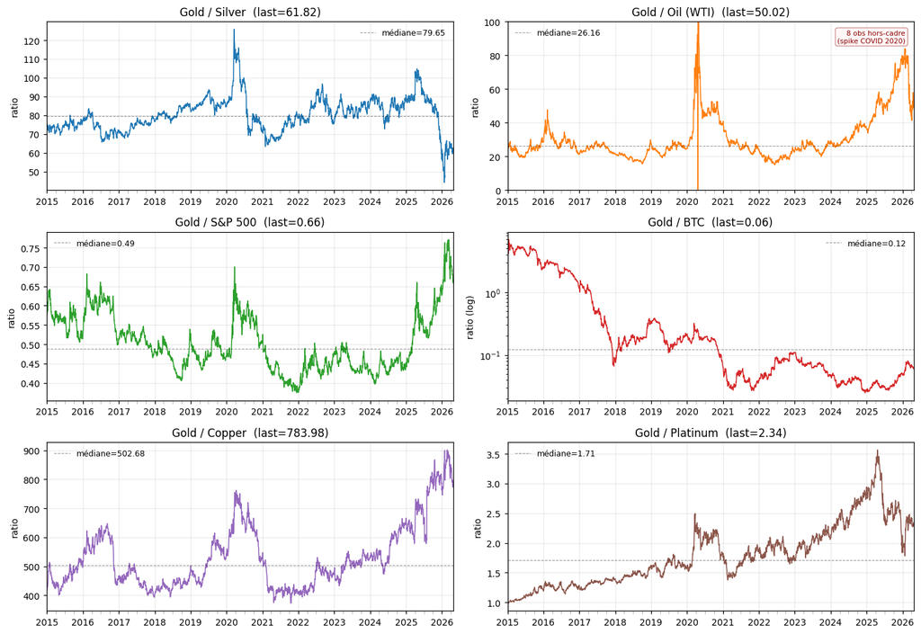

```
  > Gold/Silver ratio = 61.8 (médiane post-2015 = 79.7) — proxy de la peur macro relative entre métaux monétaires. Tous panels rebasés à 2015-01 pour comparabilité ; Gold/Oil cappé à 100 (8 obs hors-cadre lors du spike COVID 2020).
```

```python
ratios_long = q("""
    SELECT date, metric, value
    FROM read_parquet('{glob}', union_by_name=true)
    WHERE source = 'miners_yahoo'
      AND metric LIKE 'gold_%_ratio'
""")
ratios = (ratios_long.assign(date=lambda d: pd.to_datetime(d["date"]))
                     .pivot_table(index="date", columns="metric",
                                  values="value", aggfunc="last")
                     .sort_index())

# Date min commune = 2015-01-01 pour comparabilité visuelle
XMIN = pd.Timestamp("2015-01-01")

fig, axes = plt.subplots(3, 2, figsize=(13, 9))
plot_specs = [
    ("gold_silver_ratio",   "tab:blue",   "Gold / Silver",   None,        False),
    ("gold_oil_ratio",      "tab:orange", "Gold / Oil (WTI)", (0, 100),   False),
    ("gold_sp500_ratio",    "tab:green",  "Gold / S&P 500",  None,        False),
    ("gold_btc_ratio",      "tab:red",    "Gold / BTC",      None,        True),
    ("gold_copper_ratio",   "tab:purple", "Gold / Copper",   None,        False),
    ("gold_platinum_ratio", "tab:brown",  "Gold / Platinum", None,        False),
]
oil_clipped_n = 0
for ax, (col, color, title, ylim, log) in zip(axes.flat, plot_specs):
    if col not in ratios.columns:
        ax.set_title(f"{title} — n/a"); fmt_date_axis(ax); continue
    s = ratios[col].dropna()
    s = s[s.index >= XMIN]
    if insufficient_history(ax, s):
        ax.set_title(title); continue
    ax.plot(s.index, s.values, color=color, lw=1)
    median = s.median()
    ax.axhline(median, color="k", ls="--", alpha=0.4, lw=0.7,
               label=f"médiane={median:.2f}")
    ax.set_title(f"{title}  (last={s.iloc[-1]:.2f})")
    ax.set_ylabel("ratio (log)" if log else "ratio")
    ax.set_xlim(XMIN, s.index.max())
    if log:
        ax.set_yscale("log")
    if ylim is not None:
        n_out = int((s > ylim[1]).sum() + (s < ylim[0]).sum())
        if n_out:
            oil_clipped_n = n_out
            ax.annotate(f"{n_out} obs hors-cadre\n(spike COVID 2020)",
                        xy=(0.98, 0.95), xycoords="axes fraction",
                        ha="right", va="top", fontsize=7, color="darkred",
                        bbox=dict(boxstyle="round,pad=0.3", fc="#fff5f5",
                                  ec="darkred", alpha=0.7, lw=0.5))
        ax.set_ylim(*ylim)
    ax.legend(loc="best", frameon=False)
    fmt_date_axis(ax)
plt.tight_layout(); plt.show()

if "gold_silver_ratio" in ratios.columns:
    gs = ratios["gold_silver_ratio"].dropna()
    gs = gs[gs.index >= XMIN]
    caption(f"Gold/Silver ratio = {gs.iloc[-1]:.1f} (médiane post-2015 = {gs.median():.1f}) — proxy de la peur macro relative entre métaux monétaires. Tous panels rebasés à 2015-01 pour comparabilité ; Gold/Oil cappé à 100 ({oil_clipped_n} obs hors-cadre lors du spike COVID 2020).")
```

## 4. ETF flows — GLD, IAU, GDX, GDXJ

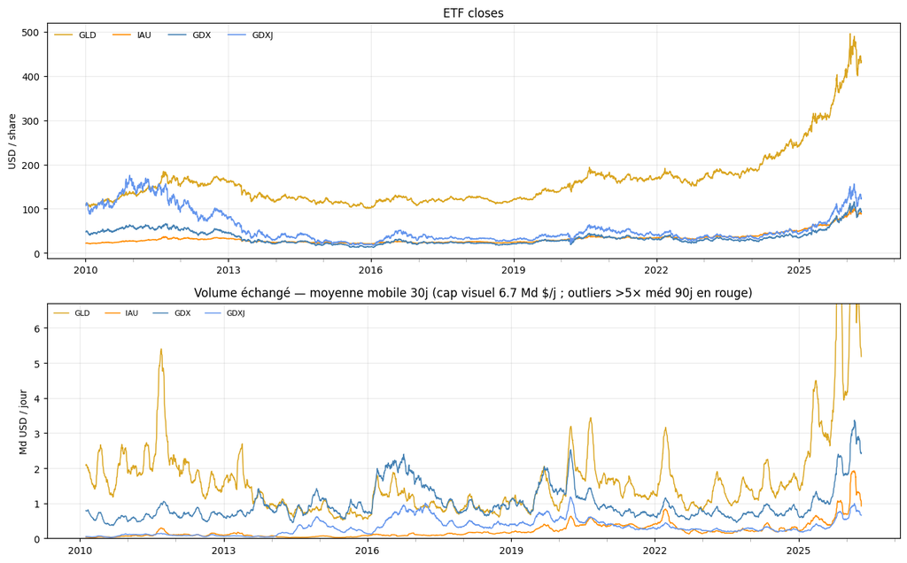

```
  > $volume 30j moyens (Md $/j) — GLD=6.25, GDX=2.72, IAU=1.25, GDXJ=0.75 — GLD reste l'instrument institutionnel dominant. 0 outlier-days marqués en rouge.
```

```python
etf_long = q("""
    SELECT date, metric, value
    FROM read_parquet('{glob}', union_by_name=true)
    WHERE source = 'etf_holdings'
      AND metric ~ '^etf_(gld|iau|gdx|gdxj|sgol|phys|sil|silj|slv)_(close_usd|dollar_volume|volume_shares)$'
""")
etf = (etf_long.assign(date=lambda d: pd.to_datetime(d["date"]))
               .pivot_table(index="date", columns="metric",
                            values="value", aggfunc="last")
               .sort_index())

fig, (ax1, ax2) = plt.subplots(2, 1, figsize=(12, 7.5))

unit_close = unit_for("etf_gld_close_usd", "usd")
for col, color in [("etf_gld_close_usd",  "goldenrod"),
                   ("etf_iau_close_usd",  "darkorange"),
                   ("etf_gdx_close_usd",  "steelblue"),
                   ("etf_gdxj_close_usd", "cornflowerblue")]:
    if col in etf.columns:
        s = etf[col].dropna()
        ax1.plot(s.index, s, lw=1.1, color=color,
                 label=col.replace("etf_", "").replace("_close_usd", "").upper())
ax1.set_title("ETF closes")
ax1.set_ylabel(f"{unit_close.upper()} / share")
ax1.legend(loc="upper left", ncol=4, frameon=False)
fmt_date_axis(ax1)

# Volume 30j moyen — ligne continue + scatter rouge sur outliers > 5× médiane 90j
# Cap visuel = 5× médiane long-terme pour éviter d'écraser la lecture.
vol_cols = [c for c in etf.columns if c.endswith("_dollar_volume")]
vol_30d = etf[vol_cols].rolling(30).mean() / 1e9  # Md USD/jour

flagged_total = 0
out_pts = {}
TARGETS = ["etf_gld_dollar_volume","etf_iau_dollar_volume",
           "etf_gdx_dollar_volume","etf_gdxj_dollar_volume"]
COLORS = {"etf_gld_dollar_volume":"goldenrod","etf_iau_dollar_volume":"darkorange",
          "etf_gdx_dollar_volume":"steelblue","etf_gdxj_dollar_volume":"cornflowerblue"}
for col in TARGETS:
    if col not in vol_30d.columns: continue
    s = vol_30d[col].dropna()
    if s.empty: continue
    med90 = s.rolling(90, min_periods=30).median()
    flagged = (s > 5 * med90).fillna(False)
    n_flag = int(flagged.sum())
    flagged_total += n_flag
    label = col.replace("etf_", "").replace("_dollar_volume", "").upper()
    ax2.plot(s.index, s, lw=1, color=COLORS[col], label=label)
    if n_flag:
        out_pts[label] = (s.index[flagged], s[flagged])

# Cap visuel : 5× médiane LT du flux le plus élevé (GLD), arrondi
all_med = vol_30d[TARGETS[0]].median() if TARGETS[0] in vol_30d.columns else 1.0
yhi = max(3.0, 5 * all_med)
ax2.set_ylim(0, yhi)

# Overlay scatter sur les outliers (capés au plafond pour rester visibles)
for label, (idx, vals) in out_pts.items():
    capped = vals.clip(upper=yhi * 0.97)
    ax2.scatter(idx, capped, s=18, c="red", marker="o",
                edgecolor="black", linewidth=0.4, zorder=5,
                label=f"outlier {label} (>5× méd 90j)" if label == list(out_pts)[0] else None)

ax2.set_title(f"Volume échangé — moyenne mobile 30j (cap visuel {yhi:.1f} Md $/j ; "
              f"outliers >5× méd 90j en rouge)")
ax2.set_ylabel("Md USD / jour")
ax2.legend(loc="upper left", ncol=5, frameon=False, fontsize=7)
fmt_date_axis(ax2)
plt.tight_layout(); plt.show()

last30 = vol_30d.tail(30).mean()
caption(
    f"$volume 30j moyens (Md $/j) — GLD={last30.get('etf_gld_dollar_volume',0):.2f}, "
    f"GDX={last30.get('etf_gdx_dollar_volume',0):.2f}, "
    f"IAU={last30.get('etf_iau_dollar_volume',0):.2f}, "
    f"GDXJ={last30.get('etf_gdxj_dollar_volume',0):.2f} — "
    f"GLD reste l'instrument institutionnel dominant. "
    f"{flagged_total} outlier-days marqués en rouge."
)
```

## 5. CFTC COT — positionnement spéculatif

`gold_mm_net` = Managed Money long − short (hedge funds discrétionnaires + CTA). Historiquement, des extrêmes (>250k contracts net long ou <50k) ont précédé des reversal courts. `gold_open_interest` mesure la profondeur du marché futures.

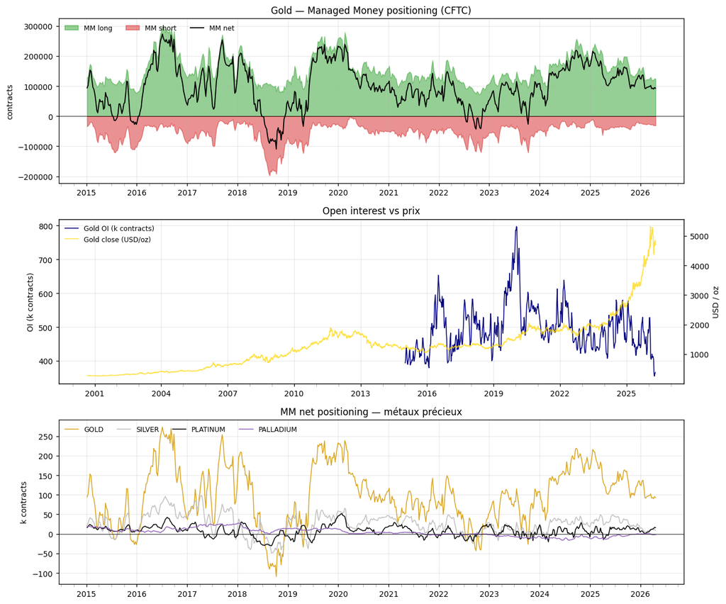

```
  > Managed Money net gold = +93k contracts — long modéré.
```

```python
cot_long = q("""
    SELECT date, metric, value
    FROM read_parquet('{glob}', union_by_name=true)
    WHERE source = 'cftc_cot'
      AND metric ~ '^(gold|silver|platinum|palladium|copper)_(mm_long|mm_short|mm_net|open_interest)$'
""")
cot = (cot_long.assign(date=lambda d: pd.to_datetime(d["date"]))
               .pivot_table(index="date", columns="metric",
                            values="value", aggfunc="last")
               .sort_index().ffill())

gold_long = q("""
    SELECT date, value AS gold_close
    FROM read_parquet('{glob}', union_by_name=true)
    WHERE source = 'yahoo' AND metric = 'gold_futures_front_close'
""")
gold_price = (gold_long.assign(date=lambda d: pd.to_datetime(d["date"]))
                       .set_index("date").sort_index())

fig, (ax1, ax2, ax3) = plt.subplots(3, 1, figsize=(12, 10))

ax1.fill_between(cot.index, 0, cot["gold_mm_long"],   color="tab:green", alpha=0.5, label="MM long")
ax1.fill_between(cot.index, 0, -cot["gold_mm_short"], color="tab:red",   alpha=0.5, label="MM short")
ax1.plot(cot.index, cot["gold_mm_net"], "k-", lw=1.2, label="MM net")
ax1.axhline(0, color="k", lw=0.5)
ax1.set_title("Gold — Managed Money positioning (CFTC)")
ax1.set_ylabel("contracts")
ax1.legend(loc="upper left", ncol=3, frameon=False)
fmt_date_axis(ax1)

ax2.plot(cot.index, cot["gold_open_interest"] / 1e3, lw=1, color="navy",
         label="Gold OI (k contracts)")
ax2b = ax2.twinx()
ax2b.plot(gold_price.index, gold_price["gold_close"], color="gold", lw=1, alpha=0.7,
          label="Gold close (USD/oz)")
ax2b.grid(False)
ax2.set_ylabel("OI (k contracts)")
ax2b.set_ylabel("USD / oz")
ax2.set_title("Open interest vs prix")
lines = ax2.get_lines() + ax2b.get_lines()
ax2.legend(lines, [l.get_label() for l in lines], loc="upper left", frameon=False)
fmt_date_axis(ax2)

for col, color in [("gold_mm_net",     "goldenrod"),
                   ("silver_mm_net",   "silver"),
                   ("platinum_mm_net", "black"),
                   ("palladium_mm_net","tab:purple")]:
    if col in cot.columns:
        s = cot[col].dropna() / 1e3
        ax3.plot(s.index, s, lw=1, label=col.replace("_mm_net", "").upper(), color=color)
ax3.axhline(0, color="k", lw=0.5)
ax3.set_title("MM net positioning — métaux précieux")
ax3.set_ylabel("k contracts")
ax3.legend(loc="upper left", ncol=4, frameon=False)
fmt_date_axis(ax3)
plt.tight_layout(); plt.show()

last_net = cot["gold_mm_net"].dropna().iloc[-1]
caption(f"Managed Money net gold = {last_net/1e3:+.0f}k contracts — "
        f"{'fortement long' if last_net > 150000 else 'long modéré' if last_net > 50000 else 'neutre/short'}.")
```

## 6. Réserves d'or des banques centrales

Snapshot du dernier scrape Wikipedia / WGC. La concentration des top-10 explique pourquoi les annonces de **achats PBoC** ou **rapatriements Allemagne** font bouger le marché. ⚠️ Ces metrics sont des photos statiques, pas des séries temporelles (le connecteur ré-écrit chaque run).

```
Couverture banques centrales : 52 pays, total 34,979 tonnes
```

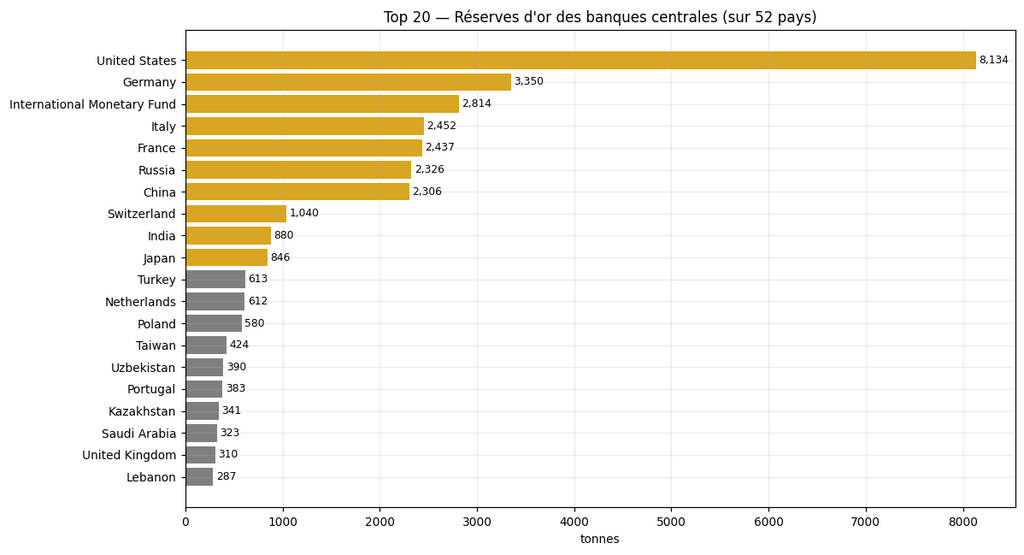

```
  > Top 5 = United States, Germany, International Monetary Fund, Italy, France (total 19,187 t = 55% du global).
```

```python
cb_long = q("""
    SELECT metric, value
    FROM read_parquet('{glob}', union_by_name=true)
    WHERE source = 'central_bank_gold' AND metric LIKE 'cb_gold_tonnes_%'
""")
cb_long["country"] = (cb_long["metric"]
    .str.replace("cb_gold_tonnes_", "", regex=False)
    .str.replace("_", " ").str.title())
cb = cb_long.set_index("country")["value"].sort_values(ascending=False)
cb = cb[cb > 0]
print(f"Couverture banques centrales : {len(cb)} pays, total {cb.sum():,.0f} tonnes")

top20 = cb.head(20)
fig, ax = plt.subplots(figsize=(11, 6))
colors = ["goldenrod" if i < 10 else "tab:gray" for i in range(len(top20))]
ax.barh(top20.index[::-1], top20.values[::-1], color=colors[::-1])
ax.set_xlabel("tonnes")
ax.set_title(f"Top 20 — Réserves d'or des banques centrales (sur {len(cb)} pays)")
for i, v in enumerate(top20.values[::-1]):
    ax.text(v + 30, i, f"{v:,.0f}", va="center", fontsize=8)
plt.tight_layout(); plt.show()

if len(cb) >= 5 and cb.sum() > 0:
    top5_share = top20.head(5).sum() / cb.sum() * 100
    caption(f"Top 5 = {', '.join(top20.head(5).index)} (total {top20.head(5).sum():,.0f} t = {top5_share:.0f}% du global).")
```

## 7. Demande physique retail — Perth Mint & Shanghai Gold Exchange

`perth_mint_*` = ventes mensuelles de produits frappés (or + argent), proxy retail Australie. Unité = **troy oz** (extraite dynamiquement du champ `unit` du parquet). SGE = bourse spot Chine, indicateur de l'appétit physique chinois (un drag négatif = arbitrage East→West).

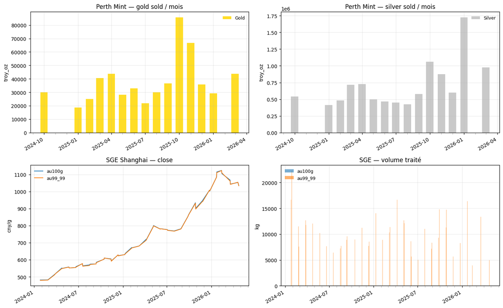

```
Perth Mint silver/gold retail ratio — last=22.4, médiane 12m=16.6
Perth Mint coverage : 15 mois (2024-10-01 → 2026-03-01)
  > Demande retail Perth Mint = 43,656 troy_oz d'or vendus le mois dernier ; flux mensuel volatil, à interpréter en moyenne trimestrielle.
```

```python
perth_long = q("""
    SELECT date, metric, value
    FROM read_parquet('{glob}', union_by_name=true)
    WHERE source = 'perth_mint'
""")
perth = (perth_long.assign(date=lambda d: pd.to_datetime(d["date"]))
                   .pivot_table(index="date", columns="metric",
                                values="value", aggfunc="last")
                   .sort_index())

sge_long = q("""
    SELECT date, metric, value
    FROM read_parquet('{glob}', union_by_name=true)
    WHERE source = 'sge'
      AND metric IN ('sge_au100g_close_cny_per_g','sge_au99_99_close_cny_per_g',
                     'sge_au100g_volume_kg','sge_au99_99_volume_kg')
""")
sge = (sge_long.assign(date=lambda d: pd.to_datetime(d["date"]))
              .pivot_table(index="date", columns="metric",
                           values="value", aggfunc="last")
              .sort_index())

fig, axes = plt.subplots(2, 2, figsize=(13, 8))

unit_gold   = unit_for("perth_mint_gold_oz",    "troy_oz")
unit_silver = unit_for("perth_mint_silver_oz",  "troy_oz")
unit_sge_p  = unit_for("sge_au100g_close_cny_per_g", "cny_per_g")
unit_sge_v  = unit_for("sge_au100g_volume_kg",  "kg")

ax = axes[0, 0]
gs = perth.get("perth_mint_gold_oz", pd.Series(dtype=float)).dropna()
if not insufficient_history(ax, gs, min_days=12,
                            msg="Historique <12 mois — signal fragile"):
    ax.bar(gs.index, gs.values, width=20, color="gold", alpha=0.85, label="Gold")
    ax.legend(frameon=False)
ax.set_title("Perth Mint — gold sold / mois")
ax.set_ylabel(unit_gold)
fmt_date_axis(ax)

ax = axes[0, 1]
ss = perth.get("perth_mint_silver_oz", pd.Series(dtype=float)).dropna()
if not insufficient_history(ax, ss, min_days=12,
                            msg="Historique <12 mois — signal fragile"):
    ax.bar(ss.index, ss.values, width=20, color="silver", alpha=0.85, label="Silver")
    ax.legend(frameon=False)
ax.set_title("Perth Mint — silver sold / mois")
ax.set_ylabel(unit_silver)
fmt_date_axis(ax)

ax = axes[1, 0]
plotted = False
for col in ["sge_au100g_close_cny_per_g", "sge_au99_99_close_cny_per_g"]:
    if col in sge.columns:
        s = sge[col].dropna()
        ax.plot(s.index, s, lw=1.2,
                label=col.replace("sge_", "").replace("_close_cny_per_g", ""))
        plotted = True
ax.set_title("SGE Shanghai — close")
ax.set_ylabel(unit_sge_p)
if plotted: ax.legend(loc="upper left", frameon=False)
fmt_date_axis(ax)

ax = axes[1, 1]
plotted = False
for col in ["sge_au100g_volume_kg", "sge_au99_99_volume_kg"]:
    if col in sge.columns:
        s = sge[col].dropna()
        ax.bar(s.index, s.values, width=1, alpha=0.6,
               label=col.replace("sge_", "").replace("_volume_kg", ""))
        plotted = True
ax.set_title("SGE — volume traité")
ax.set_ylabel(unit_sge_v)
if plotted: ax.legend(loc="upper left", frameon=False)
fmt_date_axis(ax)

plt.tight_layout(); plt.show()

if "perth_mint_silver_gold_ratio_retail" in perth.columns:
    r = perth["perth_mint_silver_gold_ratio_retail"].dropna()
    print(f"Perth Mint silver/gold retail ratio — last={r.iloc[-1]:.1f}, médiane 12m={r.tail(12).median():.1f}")
print(f"Perth Mint coverage : {len(perth)} mois ({perth.index.min().date()} → {perth.index.max().date()})")
caption(
    f"Demande retail Perth Mint = {gs.iloc[-1]:,.0f} {unit_gold} d'or vendus le mois dernier ; "
    f"flux mensuel volatil, à interpréter en moyenne trimestrielle."
)
```

## 8. Sentiment retail — Google Trends multi-région

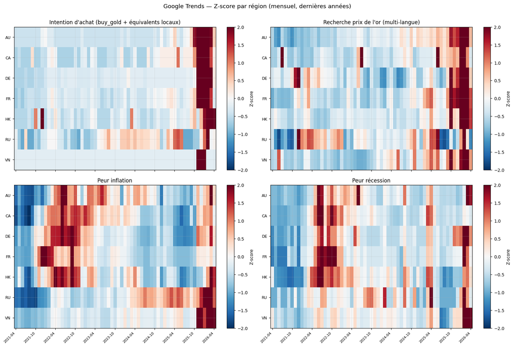

```
  > Régions avec spike > +2σ (mois courant) — buy_intent: HK | inflation: VN
```

```python
trends_raw = q("""
    SELECT date, metric, region, keyword, value
    FROM read_parquet('{glob}', union_by_name=true)
    WHERE source = 'google_trends'
""")
if trends_raw.empty:
    print("Google Trends — aucune donnée disponible (rate-limit récurrent côté Google).")
else:
    trends_raw["date"] = pd.to_datetime(trends_raw["date"])

    # 4 groupes thématiques (multi-langue mappé sur un thème)
    # buy_intent  : intention d'achat
    # gold_price  : recherche du prix
    # inflation   : peur inflation
    # recession   : peur récession
    KEYWORD_GROUPS = {
        "buy_intent": ["buy gold", "acheter or", "comprar oro", "sona bhav"],
        "gold_price": ["gold price", "goldpreis", "cours de l'or",
                       "altin fiyati", "gia vang", "giá vàng",
                       "emas hari ini", "oro"],
        "inflation":  ["inflation"],
        "recession":  ["recession"],
    }
    GROUP_TITLES = {
        "buy_intent": "Intention d'achat (buy_gold + équivalents locaux)",
        "gold_price": "Recherche prix de l'or (multi-langue)",
        "inflation":  "Peur inflation",
        "recession":  "Peur récession",
    }

    REGIONS = sorted(trends_raw["region"].dropna().unique())  # AU, CA, DE, FR, HK, RU, VN
    fig, axes = plt.subplots(2, 2, figsize=(15, 10), sharex=True)
    spike_regions = {}

    for ax, (group, kws) in zip(axes.flat, KEYWORD_GROUPS.items()):
        sub = trends_raw[trends_raw["keyword"].isin(kws)].copy()
        if sub.empty:
            ax.set_title(f"{GROUP_TITLES[group]} — n/a"); ax.axis("off"); continue
        # max sur les keywords du groupe (proxy "intensité combinée locale")
        agg = (sub.groupby(["date", "region"])["value"].max().reset_index()
                  .pivot(index="date", columns="region", values="value")
                  .reindex(columns=REGIONS).sort_index())
        # mensuel pour lisibilité
        monthly = agg.resample("ME").mean()  # date × region
        # Z-score par ligne (région)
        z = (monthly - monthly.mean()).divide(monthly.std().replace(0, 1))
        z = z.T  # region × month

        im = ax.imshow(z.values, aspect="auto", cmap="RdBu_r",
                       vmin=-2, vmax=2, interpolation="nearest")
        ax.set_yticks(range(len(z.index))); ax.set_yticklabels(z.index, fontsize=8)
        step = max(1, len(z.columns) // 10)
        ax.set_xticks(range(0, len(z.columns), step))
        ax.set_xticklabels([str(c)[:7] for c in z.columns[::step]],
                           rotation=45, ha="right", fontsize=7)
        ax.set_title(GROUP_TITLES[group])
        plt.colorbar(im, ax=ax, fraction=0.04, label="Z-score")

        # Régions avec spike > +2σ sur le dernier mois
        last = z.iloc[:, -1].dropna()
        spk = last[last > 2.0].index.tolist()
        if spk:
            spike_regions[group] = spk

    fig.suptitle("Google Trends — Z-score par région (mensuel, dernières années)",
                 fontsize=12, y=1.00)
    plt.tight_layout(); plt.show()

    if spike_regions:
        msg = " | ".join(f"{g}: {','.join(r)}" for g, r in spike_regions.items())
        caption(f"Régions avec spike > +2σ (mois courant) — {msg}")
    else:
        caption("Pas de spike > +2σ détecté sur le mois courant — niveaux normaux pour toutes les régions/thèmes.")
```

## 9. Wikipedia — pageviews (gold/inflation/hyperinflation, multilang)

Daily pageviews sur les pages-clé (gold, gold standard, fiat money, hyperinflation, Weimar Republic, federal reserve…) en EN/FR/DE/ES/TR/RU/HI/ZH. Pic = curiosité grand public, souvent corrélé à des events macro lourds.

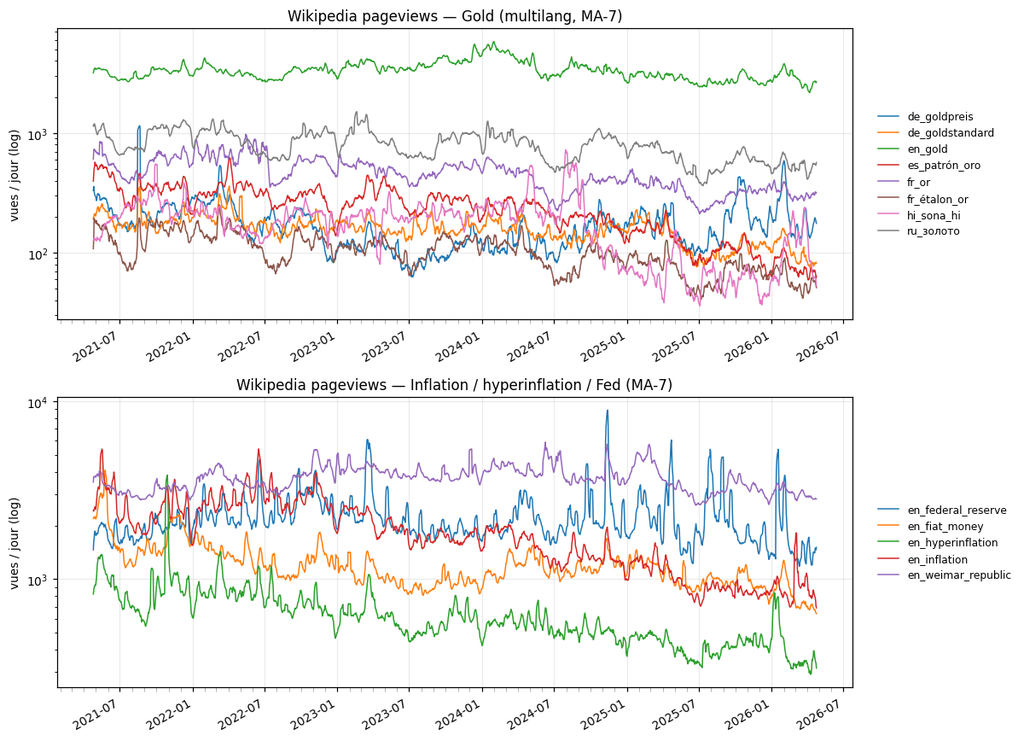

```
  > Pics de recherches macro = stress événementiel (FOMC, CPI surprise, crash, panic safe-haven). À combiner avec GDELT / Trends.
```

```python
wiki_long = q("""
    SELECT date, metric, value
    FROM read_parquet('{glob}', union_by_name=true)
    WHERE source = 'wikipedia'
""")
wiki = (wiki_long.assign(date=lambda d: pd.to_datetime(d["date"]))
                 .pivot_table(index="date", columns="metric",
                              values="value", aggfunc="last")
                 .sort_index())

fig, (ax1, ax2) = plt.subplots(2, 1, figsize=(13, 8))

gold_pages = [c for c in wiki.columns
              if any(k in c for k in ("_gold_views","_or_views","_goldpreis_views",
                                       "_goldstandard_views","_étalon_or_views",
                                       "_patrón_oro_views","_altın_views","_黃金_views",
                                       "_золото_views","_सोना_views"))]
for col in gold_pages[:8]:
    s = wiki[col].dropna()
    smooth = s.rolling(7, min_periods=1).mean()
    ax1.plot(smooth.index, smooth, lw=1, label=col.replace("wiki_", "").replace("_views", "").replace("सोना","sona_hi"))
ax1.set_title("Wikipedia pageviews — Gold (multilang, MA-7)")
ax1.set_ylabel("vues / jour (log)")
ax1.set_yscale("log")
legend_outside(ax1, ncol=1)
fmt_date_axis(ax1)

macro_pages = [c for c in wiki.columns
               if any(k in c for k in ("inflation_views","hyperinflation_views",
                                        "federal_reserve_views","fiat_money_views",
                                        "weimar_republic_views"))]
for col in macro_pages[:8]:
    s = wiki[col].dropna()
    smooth = s.rolling(7, min_periods=1).mean()
    ax2.plot(smooth.index, smooth, lw=1, label=col.replace("wiki_", "").replace("_views", "").replace("सोना","sona_hi"))
ax2.set_title("Wikipedia pageviews — Inflation / hyperinflation / Fed (MA-7)")
ax2.set_ylabel("vues / jour (log)")
ax2.set_yscale("log")
legend_outside(ax2, ncol=1)
fmt_date_axis(ax2)
plt.tight_layout(rect=[0, 0, 0.85, 1])
plt.show()

caption("Pics de recherches macro = stress événementiel (FOMC, CPI surprise, crash, panic safe-haven). À combiner avec GDELT / Trends.")
```

## 10. GDELT — volume & tone des news

Pour chaque thème (`gold_price`, `central_bank_gold`, `safe_haven`, `inflation_hedge`, `mine_disruption`, `dollar_collapse`, `bullion`, `gold_china/russia/india`) :

- `*_vol` = nombre d'articles trouvés (proxy d'attention médiatique)
- `*_tone` = polarité moyenne (positif/négatif) de Goldstein avg

Tone négatif ↑ + volume ↑ sur `mine_disruption` ou `dollar_collapse` → contexte fav. or.

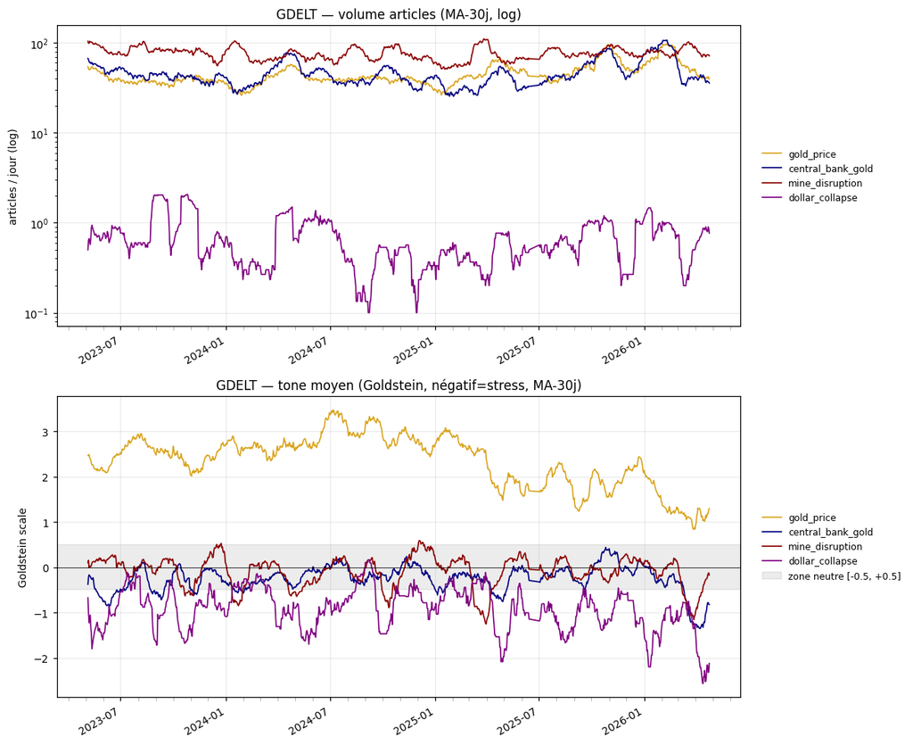

```
  > Tone actuel : gold_price=+1.30, central_bank_gold=-0.82, mine_disruption=-0.17, dollar_collapse=-2.12. Tone < -0.5 = stress soutenu, > +0.5 = couverture positive ; zone grise = bruit éditorial neutre.
```

```python
gdelt_long = q("""
    SELECT date, metric, value
    FROM read_parquet('{glob}', union_by_name=true)
    WHERE source = 'gdelt'
""")
gdelt = (gdelt_long.assign(date=lambda d: pd.to_datetime(d["date"]))
                   .pivot_table(index="date", columns="metric",
                                values="value", aggfunc="last")
                   .sort_index())

THEMES = ["gold_price", "central_bank_gold", "mine_disruption", "dollar_collapse"]
THEME_COLORS = {
    "gold_price":        "goldenrod",
    "central_bank_gold": "navy",
    "mine_disruption":   "darkred",
    "dollar_collapse":   "purple",
}

fig, (ax1, ax2) = plt.subplots(2, 1, figsize=(13, 9))

# Volume — MA 30j, log
for theme in THEMES:
    col = f"gdelt_{theme}_vol"
    if col not in gdelt.columns:
        print(f"  warn — {col} absent du parquet"); continue
    s = gdelt[col].dropna()
    smooth = s.rolling(30, min_periods=10).mean()
    ax1.plot(smooth.index, smooth, lw=1.1, color=THEME_COLORS[theme], label=theme)
ax1.set_title("GDELT — volume articles (MA-30j, log)")
ax1.set_ylabel("articles / jour (log)")
ax1.set_yscale("log")
legend_outside(ax1, ncol=1)
fmt_date_axis(ax1)

# Tone — MA 30j, bande grise neutre [-0.5, +0.5]
last_tones = {}
for theme in THEMES:
    col = f"gdelt_{theme}_tone"
    if col not in gdelt.columns:
        print(f"  warn — {col} absent du parquet"); continue
    s = gdelt[col].dropna()
    smooth = s.rolling(30, min_periods=10).mean()
    ax2.plot(smooth.index, smooth, lw=1.1, color=THEME_COLORS[theme], label=theme)
    if len(smooth.dropna()):
        last_tones[theme] = smooth.dropna().iloc[-1]
ax2.axhspan(-0.5, 0.5, color="gray", alpha=0.15, zorder=0, label="zone neutre [-0.5, +0.5]")
ax2.axhline(0, color="k", lw=0.5)
ax2.set_title("GDELT — tone moyen (Goldstein, négatif=stress, MA-30j)")
ax2.set_ylabel("Goldstein scale")
legend_outside(ax2, ncol=1)
fmt_date_axis(ax2)
plt.tight_layout(rect=[0, 0, 0.85, 1])
plt.show()

if last_tones:
    parts = ", ".join(f"{k}={v:+.2f}" for k, v in last_tones.items())
    caption(f"Tone actuel : {parts}. Tone < -0.5 = stress soutenu, > +0.5 = couverture positive ; zone grise = bruit éditorial neutre.")
else:
    caption("Volume gold news = proxy attention médiatique. (Aucune donnée tone disponible.)")
```

## 11. Stocktwits — sentiment snapshot

API Stocktwits ne fournit qu'un **snapshot** instantané (pas de séries temporelles libres). Bullish/bearish % par ticker = humeur retail à l'instant T. À cumuler dans le temps en ré-exécutant le scrape périodiquement.

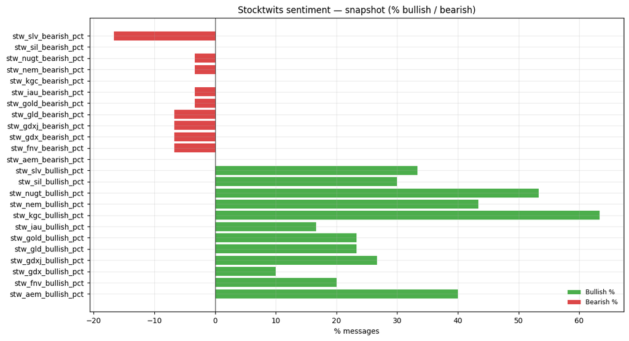

```
  > Sentiment retail snapshot — bias bullish moyen = 31.9% (n=12 tickers)
```

```python
stw = q("""
    SELECT metric, value
    FROM read_parquet('{glob}', union_by_name=true)
    WHERE source = 'stocktwits' AND (metric LIKE '%bullish_pct' OR metric LIKE '%bearish_pct')
""")

if stw.empty:
    print("Stocktwits — pas de données disponibles (API rate-limited).")
else:
    df = stw.set_index("metric")["value"].sort_index()
    bullish = df[df.index.str.contains("bullish_pct")]
    bearish = df[df.index.str.contains("bearish_pct")]
    fig, ax = plt.subplots(figsize=(11, 6))
    ax.barh(bullish.index, bullish.values, color="tab:green", alpha=0.85, label="Bullish %")
    ax.barh(bearish.index, -bearish.values, color="tab:red", alpha=0.85, label="Bearish %")
    ax.axvline(0, color="k", lw=0.5)
    ax.set_title("Stocktwits sentiment — snapshot (% bullish / bearish)")
    ax.set_xlabel("% messages")
    ax.legend(loc="lower right", frameon=False)
    plt.tight_layout(); plt.show()
    caption(f"Sentiment retail snapshot — bias bullish moyen = "
            f"{bullish.mean():.1f}% (n={len(bullish)} tickers)")
```

## 12. Risques exogènes — météo aux mines + activité sismique

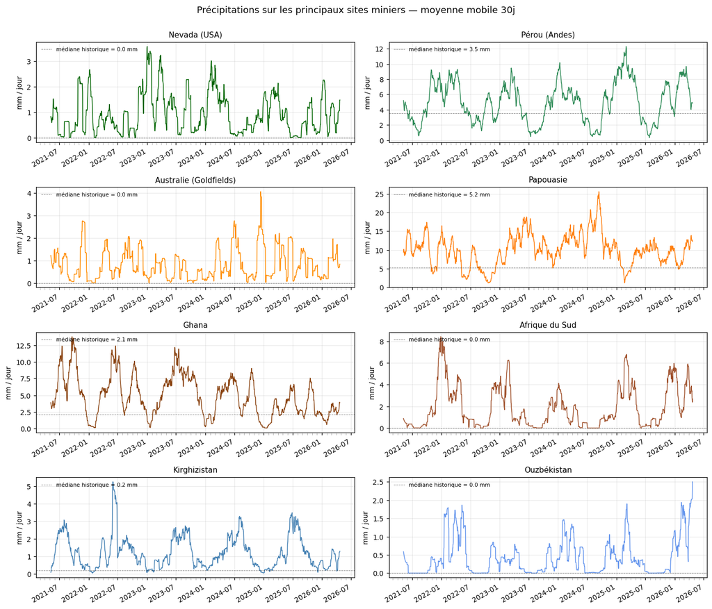

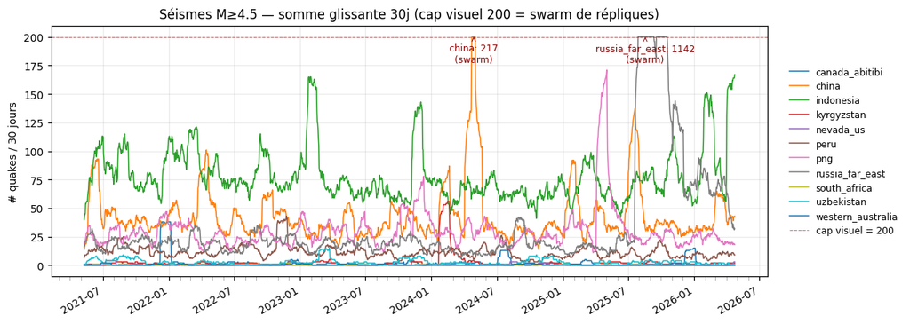

```
  > Précipitations en facet (8 sites) avec médiane historique en pointillés = déviations vs régime climatique normal. Séismes : pics > cap = essaims post-mégaséisme (ex: Russia Far East 2025-07 = M8.8 Kamtchatka). Pas de signal supply-disruption gold direct.
```

```python
precip_long = q("""
    SELECT date, metric, value
    FROM read_parquet('{glob}', union_by_name=true)
    WHERE source = 'open_meteo' AND metric LIKE '%_precipitation_sum'
""")
precip = (precip_long.assign(date=lambda d: pd.to_datetime(d["date"]))
                     .pivot_table(index="date", columns="metric",
                                  values="value", aggfunc="last")
                     .sort_index())
precip_30d = precip.rolling(30, min_periods=15).mean()

quakes_long = q("""
    SELECT date, metric, value
    FROM read_parquet('{glob}', union_by_name=true)
    WHERE source = 'usgs_earthquakes' AND metric LIKE '%_quakes_count'
""")
quakes = (quakes_long.assign(date=lambda d: pd.to_datetime(d["date"]))
                     .pivot_table(index="date", columns="metric",
                                  values="value", aggfunc="last")
                     .reindex(pd.date_range(start=quakes_long["date"].min(),
                                            end=quakes_long["date"].max(), freq="D"))
                     .fillna(0).sort_index())
quakes_30d = quakes.rolling(30, min_periods=15).sum()

# ── Panel 1 : facet 4x2 précipitations par site (couleur par région géographique)
SITE_REGION_COLOR = {
    "carlin_nv":     ("Nevada (USA)",        "darkgreen"),
    "yanacocha_pe":  ("Pérou (Andes)",        "seagreen"),
    "kalgoorlie":    ("Australie (Goldfields)", "darkorange"),
    "lihir_png":     ("Papouasie",           "tab:orange"),
    "obuasi_gh":     ("Ghana",               "saddlebrown"),
    "witwatersrand": ("Afrique du Sud",      "sienna"),
    "kumtor_kg":     ("Kirghizistan",        "steelblue"),
    "muruntau_uz":   ("Ouzbékistan",         "cornflowerblue"),
}
fig, axes = plt.subplots(4, 2, figsize=(13, 11), sharex=True)
sites_in_data = []
for ax, (site, (label, color)) in zip(axes.flat, SITE_REGION_COLOR.items()):
    col = f"weather_{site}_precipitation_sum"
    if col not in precip_30d.columns:
        ax.set_title(f"{label} — n/a"); ax.axis("off"); continue
    s = precip_30d[col].dropna()
    raw = precip[col].dropna()
    median = raw.median()
    ax.plot(s.index, s, lw=1.0, color=color)
    ax.axhline(median, color="k", ls="--", lw=0.6, alpha=0.5,
               label=f"médiane historique = {median:.1f} mm")
    ax.set_title(f"{label}", fontsize=10)
    ax.set_ylabel("mm / jour")
    ax.legend(loc="upper left", frameon=False, fontsize=7)
    sites_in_data.append(site)
    fmt_date_axis(ax)
fig.suptitle("Précipitations sur les principaux sites miniers — moyenne mobile 30j",
             fontsize=12, y=1.00)
plt.tight_layout(); plt.show()

# ── Panel 2 : séismes (inchangé, conservé tel quel)
fig2, ax2 = plt.subplots(figsize=(13, 4))
QUAKE_CAP = 200
for col in quakes_30d.columns:
    region = col.replace("usgs_", "").replace("_quakes_count", "")
    s = quakes_30d[col].dropna()
    if s.empty: continue
    s_capped = s.clip(upper=QUAKE_CAP)
    ax2.plot(s_capped.index, s_capped, lw=1, label=region)
    spikes = s[s > QUAKE_CAP]
    if len(spikes):
        peak_dt = spikes.idxmax()
        peak_val = float(s.loc[peak_dt])
        ax2.annotate(f"{region}: {peak_val:.0f}\n(swarm)",
                     xy=(peak_dt, QUAKE_CAP), xytext=(0, -22),
                     textcoords="offset points",
                     fontsize=8, color="darkred", ha="center",
                     arrowprops=dict(arrowstyle="->", color="darkred", lw=0.6))
ax2.axhline(QUAKE_CAP, color="darkred", ls="--", lw=0.7, alpha=0.5,
            label=f"cap visuel = {QUAKE_CAP}")
ax2.set_title(f"Séismes M≥4.5 — somme glissante 30j (cap visuel {QUAKE_CAP} = swarm de répliques)")
ax2.set_ylabel("# quakes / 30 jours")
legend_outside(ax2, ncol=1)
fmt_date_axis(ax2)
plt.tight_layout(rect=[0, 0, 0.85, 1])
plt.show()

caption(f"Précipitations en facet ({len(sites_in_data)} sites) avec médiane historique en pointillés "
        "= déviations vs régime climatique normal. Séismes : pics > cap = essaims post-mégaséisme "
        "(ex: Russia Far East 2025-07 = M8.8 Kamtchatka). Pas de signal supply-disruption gold direct.")
```

## 13. Cross-asset — matrice de corrélation des returns

Corrélations rolling 90j vs Gold pour identifier les régimes de risk-on/off, dollar-driven, ou recouplage avec les real yields.

```
Matrice corrélation : 9 actifs, fenêtre 2014-09-18 → 2026-04-25 (4238 obs)
```

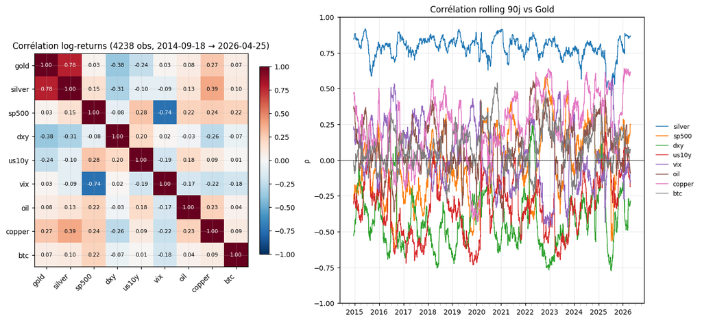

```
  > Gold corrélations (log-ret, full sample) — silver=+0.78, copper=+0.27, oil=+0.08, btc=+0.07, sp500=+0.03, vix=+0.03, us10y=-0.24, dxy=-0.38
```

```python
# Diagnostic : récupérer les vrais noms de metrics oil/copper/btc dans yahoo
diag = q("""
    SELECT DISTINCT metric
    FROM read_parquet('{glob}', union_by_name=true)
    WHERE source='yahoo'
      AND (metric LIKE '%oil%' OR metric LIKE '%wti%'
        OR metric LIKE '%copper%' OR metric LIKE '%hg%'
        OR metric LIKE '%btc%' OR metric LIKE '%bitcoin%' OR metric LIKE '%cl_%')
""")
OIL    = "wti_crude_close"      if "wti_crude_close"      in diag["metric"].values else None
COPPER = "copper_futures_close" if "copper_futures_close" in diag["metric"].values else None
BTC    = "bitcoin_close"        if "bitcoin_close"        in diag["metric"].values else None
for label, m in [("oil", OIL), ("copper", COPPER), ("btc", BTC)]:
    if m is None:
        print(f"  warn — {label} introuvable dans yahoo, exclu de la matrice")

WANTED = ["gold_futures_front_close", "silver_futures_front_close",
          "sp500_close", "dxy_close", "vix_close", "us10y_yield_close",
          OIL, COPPER, BTC]
WANTED = [m for m in WANTED if m]

cross = q(f"""
    SELECT date, metric, value
    FROM read_parquet('{{glob}}', union_by_name=true)
    WHERE source IN ('yahoo','fred')
      AND metric IN ({", ".join(repr(m) for m in WANTED)})
""")
wide_x = (cross.assign(date=lambda d: pd.to_datetime(d["date"]))
              .pivot_table(index="date", columns="metric",
                           values="value", aggfunc="last")
              .sort_index().ffill())

# Garder uniquement les colonnes ayant >=1000 obs avant dropna
keep = [c for c in wide_x.columns if wide_x[c].dropna().shape[0] >= 1000]
wide_x = wide_x[keep].dropna(how="any")  # fenêtre commune toutes séries

# Renommer pour lisibilité
RENAME = {"gold_futures_front_close":"gold","silver_futures_front_close":"silver",
          "sp500_close":"sp500","dxy_close":"dxy","vix_close":"vix",
          "us10y_yield_close":"us10y","wti_crude_close":"oil",
          "copper_futures_close":"copper","bitcoin_close":"btc"}
wide_x = wide_x.rename(columns=RENAME)

ret = np.log(wide_x.where(wide_x > 0)).diff().dropna(how="all")

print(f"Matrice corrélation : {ret.shape[1]} actifs, fenêtre {ret.index.min().date()} → {ret.index.max().date()} ({len(ret)} obs)")

fig, (ax1, ax2) = plt.subplots(1, 2, figsize=(15, 6),
                                gridspec_kw={"width_ratios": [1, 1.3]})

# Ordre cohérent : précieux → equity → fx/yields → commodités → crypto
ORDER = ["gold","silver","sp500","dxy","us10y","vix","oil","copper","btc"]
ordered = [c for c in ORDER if c in ret.columns]
ret = ret[ordered]
corr = ret.corr()

im = ax1.imshow(corr.values, vmin=-1, vmax=1, cmap="RdBu_r")
ax1.set_xticks(range(len(corr))); ax1.set_yticks(range(len(corr)))
ax1.set_xticklabels(corr.columns, rotation=45, ha="right")
ax1.set_yticklabels(corr.index)
for i in range(len(corr)):
    for j in range(len(corr)):
        ax1.text(j, i, f"{corr.values[i,j]:.2f}", ha="center", va="center",
                 fontsize=7, color="black" if abs(corr.values[i,j]) < 0.6 else "white")
ax1.set_title(f"Corrélation log-returns ({len(ret)} obs, {ret.index.min().date()} → {ret.index.max().date()})")
plt.colorbar(im, ax=ax1, fraction=0.04)

if "gold" in ret.columns:
    others = [c for c in ret.columns if c != "gold"]
    rolling_corr = pd.concat(
        [ret[c].rolling(90).corr(ret["gold"]).rename(c) for c in others],
        axis=1)
    for col in rolling_corr.columns:
        s = rolling_corr[col].dropna()
        if len(s):
            ax2.plot(s.index, s, lw=1, label=col)
    ax2.axhline(0, color="k", lw=0.5)
    ax2.set_title("Corrélation rolling 90j vs Gold")
    ax2.set_ylabel("ρ")
    ax2.set_ylim(-1, 1)
    legend_outside(ax2, ncol=1)
    fmt_date_axis(ax2)
plt.tight_layout(rect=[0, 0, 0.86, 1])
plt.show()

if "gold" in corr.columns:
    g = corr["gold"].drop("gold").sort_values(ascending=False)
    caption("Gold corrélations (log-ret, full sample) — "
            + ", ".join(f"{k}={v:+.2f}" for k, v in g.items()))
```

## 14. Récap & gaps de données

Stats agrégées : par source = nb metrics, profondeur historique, nb d'observations, dernière date. Plus la liste des limitations connues (sources qui plafonnent, deprecated, etc.).

```python
recap = q("""
    SELECT source,
           COUNT(*)                            AS rows,
           COUNT(DISTINCT metric)              AS metrics,
           MIN(date)                           AS first_date,
           MAX(date)                           AS last_date,
           ROUND(EXTRACT(EPOCH FROM (MAX(date::TIMESTAMP) - MIN(date::TIMESTAMP)))/86400,
                 0)                            AS span_days
    FROM read_parquet('{glob}', union_by_name=true)
    GROUP BY source
    ORDER BY rows DESC
""")
print("=== Récapitulatif des connecteurs ===")
print(recap.to_string(index=False))
```

```
=== Récapitulatif des connecteurs ===
           source    rows  metrics          first_date           last_date  span_days
            yahoo 2149830      390 1996-01-01 00:00:00 2026-04-25 00:00:00    11072.0
     etf_holdings  170437       50 2008-09-30 00:00:00 2026-04-24 00:00:00     6415.0
  historical_long  159585       35 2005-01-03 00:00:00 2026-04-24 00:00:00     7781.0
       open_meteo   87648       48 2021-04-24 00:00:00 2026-04-23 00:00:00     1825.0
             fred   77221       30 2010-01-01 00:00:00 2026-04-27 00:00:00     5960.0
     binance_gold   70843       80 2019-01-01 00:00:00 2026-04-25 00:00:00     2671.0
     miners_yahoo   51743       11 2000-08-30 00:00:00 2026-04-24 00:00:00     9368.0
    google_trends   35235      135 2021-04-25 00:00:00 2026-04-19 00:00:00     1820.0
        wikipedia   34694       19 2021-04-25 00:00:00 2026-04-24 00:00:00     1825.0
            gdelt   23738       22 2023-04-26 00:00:00 2026-04-25 00:00:00     1095.0
         cftc_cot   23220       45 2015-01-06 00:00:00 2026-04-21 00:00:00     4123.0
        defillama   23180       56 2017-09-27 00:00:00 2026-04-25 00:00:00     3132.0
 usgs_earthquakes   16791       33 2021-04-26 00:00:00 2026-04-24 00:00:00     1824.0
     treasury_tga   15303        6 2010-01-04 00:00:00 2026-04-23 00:00:00     5953.0
        sec_edgar    7300       64 2002-02-01 00:00:00 2026-04-23 00:00:00     8847.0
          us_mint    1260        4 1986-10-01 00:00:00 2012-12-01 00:00:00     9558.0
              sge     985       24 2024-01-26 00:00:00 2026-04-24 00:00:00      819.0
   coingecko_gold     568       28 2026-01-26 00:00:00 2026-04-25 12:29:31       90.0
      mining_news     147       14 2026-03-22 09:32:14 2026-04-24 11:06:00       33.0
       stocktwits      60       60 2026-04-25 00:00:00 2026-04-25 00:00:00        0.0
       perth_mint      59        4 2024-10-01 00:00:00 2026-03-01 00:00:00      516.0
central_bank_gold      54       54 2026-04-25 00:00:00 2026-04-25 00:00:00        0.0
```

### Limitations connues

| Source | Limitation |
| --- | --- |
| `central_bank_gold` | Snapshot annuel (Wikipedia / WGC), pas de série temporelle |
| `stocktwits` | Snapshot temps-réel par run — série construite par accumulation |
| `mining_news` | RSS sans backfill, ne capture que ce qui sort depuis le démarrage du connecteur |
| `google_trends` | Rate-limited par Google (`/sorry/`), relancer en plusieurs passes ou via proxy |
| `coingecko_gold` | 90 jours daily max (free tier) |
| `xaut_usdt` (Binance) | Listing récent → peu de profondeur |
| `perth_mint` | URLs disponibles depuis octobre 2024 seulement |
| `defi_tether_gold_tvl` | Données depuis juillet 2024 seulement |